# A Visualization of U.S. Couples’ Money Arrangements

Joanna R. Pepin

2022-10-21

# Abstract

Using newly available nationally representative U.S. data from the [National Couples’ Health and Time Study](https://www.icpsr.umich.edu/web/DSDR/studies/38417), this visualization presents 2020–2021 estimates of couples’ (n=3,396) money arrangements by marital and parental status, age group, and for different-gender and same-gender couples. It shows cohabiting couples continue to be much less likely than married couples to pool all their money, and the gap is apparent across key demographic characteristics. Among married couples, 66% of different-gender couples put all their money together, compared with 45% of women partnered with women and 50% of men partnered with men. Young couples are as likely as older couples to put all money together when legally married.

### Keywords

money, couples, marriage, cohabitation, visualization

A recent survey experiment showed the most commonly selected money arrangement for a fictional couple was to combine some of their money and keep some money separate (Pepin (2019)). Whether U.S. couples’ behaviors have changed in ways consistent with these public beliefs has remained an open empirical question because the most recent publicly available data on U.S. couples’ money arrangements comes from the 2012 International Social Survey Programme Family and Changing Gender Roles module. This 10-year gap has hindered crucial knowledge about societal trends in the pursuit of autonomy vs. collectivism in relationships. Couples’ treatment of money also has important substantive implications regarding relationship quality and persistent gender inequality within families. Moreover, a comparison between different-gender and same-gender couples’ money arrangements has been unobtainable using nationally representative survey data until now.

Figure 1 presents updated estimates of couples’ approaches to money using 2020–2021 data from the National Couples’ Health and Time Study (NCHAT), a nationally representative sample of married and cohabiting couples living in the United States (Kamp Dush and Manning (2022)). NCHAT oversampled sexual and gender diverse families, and is nationally representative of married and cohabiting couples (aged 20–60) living in the United States. Couples’ money arrangements are presented by marital and parental status, for different-gender and same-gender couples, and by age group. Results are disaggregated by legal marital status, which has consistently been found to be the determining characteristic influencing couples’ integration of money (Eickmeyer, Manning, and Brown (2019)). Each panel in the figure contains a waffle chart consisting of 100 smaller squares colored according to the proportion of couples who report they (1) put all of their money together, (2) put some money together, or (3) keep all of their money separate. Additional details are available in the [online supplement](https://jrpepin.github.io/NCHAT_Money/Supplementary-Material.html) and data access and replication code are available at: https://github.com/jrpepin/NCHAT_Money.

Differences by marital status are apparent, with 66% of married couples reporting they pool everything compared with 23% of cohabiting couples taking a complete pooling approach (p<.05). The marriage-cohabitation gap is visible across sub-groups and chi-squared tests confirm it is statistically significantly different within each demographic characteristic (p<.05). Married couples who are parenting are more likely than married couples who are not parenting to put all their money together (p<.05). Two-thirds of married different-gender couples put all of their money together compared with 50% of married men partnered with men and 45% of married women partnered with women (p<.05). Cohabiting couples’ approaches to money are relatively consistent within sub-groups and are not statistically significantly different.

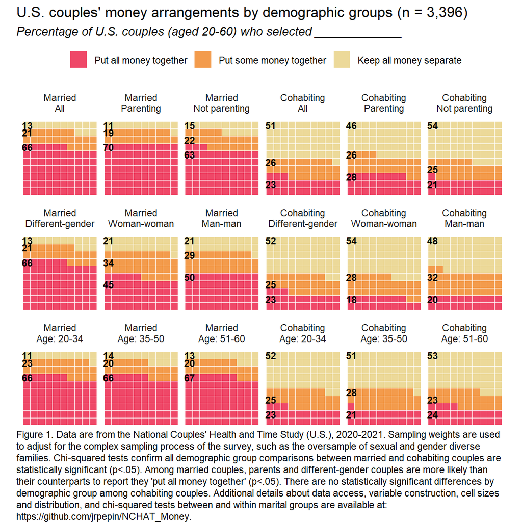

Increases in couples more often cohabiting before marrying, attitude data (Pepin (2019)), and behavioral estimates from outside the U.S. (Hu (2021)) and from non-representative U.S. samples (Bank of America (2018)) all suggest younger couples may be more likely than their older counterparts to keep their finances separate. Yet, this data visualization shows that money arrangements look remarkably similar across age groups. About two-thirds of married couples pool their money, regardless of age, compared with less than one-quarter of cohabitors (p<.05).

Overall, the figure shows that U.S. couples’ money arrangements remain starkly differentiated by marital status and cohort differences are less apparent than expected based on empirical data from other contexts and composition changes among U.S. families that are associated with a reduction in pooled finances. These bivariate statistics open many possibilities for use of NCHAT data to answer further questions related to U.S. couples’ treatment of money that have so far remained elusive.

# References

Bank of America. 2018. “Better Money Habits Millennial Report.” https://bettermoneyhabits.bankofamerica.com/content/dam/bmh/pdf/ar6vnln9-boa-bmh-millennial-report-winter-2018-final2.pdf.

Eickmeyer, Kasey J., Wendy D. Manning, and Susan L. Brown. 2019. “What’s Mine Is Ours? Income Pooling in American Families.” *Journal of Marriage and Family* 81 (4): 968–78. https://doi.org/10.1111/jomf.12565.

Hu, Yang. 2021. “Divergent Gender Revolutions: Cohort Changes in Household Financial Management Across Income Gradients.” *Gender & Society* 35 (5): 746–77. https://doi.org/10.1177/08912432211036912.

Kamp Dush, Claire M., and Wendy D. Manning. 2022. “National Couples’ Health and Time Study (NCHAT), United States, 2020-2021.” Interuniversity Consortium for Political and Social Research. https://doi.org/10.3886/ICPSR38417.V1.

Pepin, Joanna R. 2019. “Beliefs About Money in Families: Balancing Unity, Autonomy, and Gender Equality.” *Journal of Marriage and Family* 81 (2): 361–79. https://doi.org/10.1111/jomf.12554.